# ps5-rmarkdown

Cassie Hoang

2023-02-16

## Load Data

```r
library(tidyverse)
```

2. Load data. How many rows/columns do we have?

```r
gapminder <- read_delim("gapminder.csv.bz2")
nrow(gapminder)
```

```
## [1] 13055
```

```r
ncol(gapminder)
```

```
## [1] 25
```

3. Print a small sample of data.

```r
gapminder %>%
  head(3)
```

```
## # A tibble: 3 × 25
##   iso3  name  iso2  region sub-r…¹ inter…²  time total…³ ferti…⁴ lifeE…⁵ child…⁶
##   <chr> <chr> <chr> <chr>  <chr>   <chr>   <dbl>   <dbl>   <dbl>   <dbl>   <dbl>
## 1 ABW   Aruba AW    Ameri… Latin … Caribb…  1960   54211    4.82    65.7      NA
## 2 ABW   Aruba AW    Ameri… Latin … Caribb…  1961   55438    4.66    66.1      NA
## 3 ABW   Aruba AW    Ameri… Latin … Caribb…  1962   56225    4.47    66.4      NA
## # … with 14 more variables: youthFemaleLiteracy <dbl>, youthMaleLiteracy <dbl>,
## #   adultLiteracy <dbl>, GDP_PC <dbl>, accessElectricity <dbl>,
## #   agriculturalLand <dbl>, agricultureTractors <dbl>, cerealProduction <dbl>,
## #   fertilizerHa <dbl>, co2 <dbl>, greenhouseGases <dbl>, co2_PC <dbl>,
## #   pm2.5_35 <dbl>, battleDeaths <dbl>, and abbreviated variable names
## #   ¹`sub-region`, ²`intermediate-region`, ³totalPopulation, ⁴fertilityRate,
## #   ⁵lifeExpectancy, ⁶childMortality
```

## Descriptive Statistics

1. How may countries are in the data set? Analyze all three: *iso2*, *iso3*, and *name*.

```r
gapminder %>%
  summarize(num_iso2 = n_distinct(iso2), num_iso3 = n_distinct(iso3),
            num_names = n_distinct(name))
```

```
## # A tibble: 1 × 3
##   num_iso2 num_iso3 num_names
##      <int>    <int>     <int>
## 1      249      253       250
```

There are 249 2-letter country codes, 253 3-letter country codes, & 250 names.

2. If you did this correctly, you saw that there are more names than iso-2 codes, and there are even more iso-3 codes. What is going on? Can you find out?
1. Find how many names are there for each iso-2 code. Are there any iso-2 codes that correspond to more than one name? What are these countries?

```r
gapminder %>%
  group_by(iso2) %>%
  summarize(n  = n_distinct(name)) %>%
  arrange(desc(n))
```

```
## # A tibble: 249 × 2
##    iso2      n
##    <chr> <int>
##  1 <NA>      2
##  2 AD        1
##  3 AE        1
##  4 AF        1
##  5 AG        1
##  6 AI        1
##  7 AL        1
##  8 AM        1
##  9 AO        1
## 10 AQ        1
## # … with 239 more rows
```

2. Now repeat the same for name and iso3-code. Are there country names that have more than one iso3-code? What are these countries?

```r
gapminder %>%
  group_by(iso3) %>%
  summarize(n  = n_distinct(name)) %>%
  arrange(desc(n))
```

```
## # A tibble: 253 × 2
##    iso3      n
##    <chr> <int>
##  1 ABW       1
##  2 AFG       1
##  3 AGO       1
##  4 AIA       1
##  5 ALA       1
##  6 ALB       1
##  7 AND       1
##  8 ARE       1
##  9 ARG       1
## 10 ARM       1
## # … with 243 more rows
```

3. What is the minimum and maximum year in these data?

```r
max(gapminder$time)
```

```
## [1] NA
```

```r
min(gapminder$time)
```

```
## [1] NA
```

## CO2 Emissions

1. How many missing co2 emissions are there for each year? Analyze both missing *CO2* and *co2_PC*. Which years have most missing data?

```r
gapminder %>%
  group_by(time) %>%
  summarize(sum(is.na(co2)))
```

```
## # A tibble: 61 × 2
##     time `sum(is.na(co2))`
##    <dbl>             <int>
##  1  1960                60
##  2  1961                60
##  3  1962                58
##  4  1963                57
##  5  1964                51
##  6  1965                51
##  7  1966                51
##  8  1967                51
##  9  1968                51
## 10  1969                51
## # … with 51 more rows
```

For CO2, years 2017, 2018, and 2019 have the most missing data.

```r
gapminder %>%
  group_by(time) %>%
  summarize(sum(is.na(co2_PC)))
```

```
## # A tibble: 61 × 2
##     time `sum(is.na(co2_PC))`
##    <dbl>                <int>
##  1  1960                   60
##  2  1961                   60
##  3  1962                   58
##  4  1963                   57
##  5  1964                   51
##  6  1965                   51
##  7  1966                   51
##  8  1967                   51
##  9  1968                   51
## 10  1969                   51
## # … with 51 more rows
```

Similar to CO2, 2017, 2018, and 2019 have the most missing data for co2_PC.

2. Make a plot of total CO2 emissions over time for the U.S, China, and India. Add a few more countries of your choice. Explain what do you see.

```r
countries <- c("United States of America", "China", "India", "Australia", "Thailand")
co2_emissions <- gapminder %>%
  filter(name %in% countries) %>%
  group_by(name, time) %>%
  summarize(co2 = sum(co2, na.rm = TRUE))
```

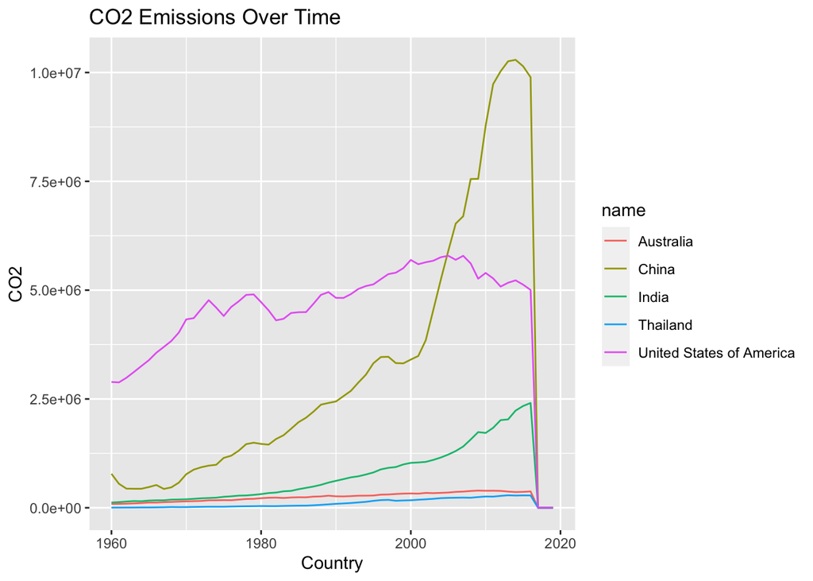

```r
ggplot(co2_emissions, aes(x = time, y = co2, color = name)) +
  geom_line() +
  labs(title = "CO2 Emissions Over Time",
       x = "Country",
       y = "CO2")
```

Between the countries, China and the USA reach the highest amounts of CO2 emissions. USA peaks before the year 2020. The other countries, Australia, India, and Thailand have a similar steady pattern, with a higher increase in India towards the later years.

3. Now let’s analyze the CO2 emissions per capita ( *co2_PC* ). Make a similar plot of the same countries. What does this figure suggest?

```r
co2PC_continents <- gapminder %>%
  filter(name %in% countries) %>%
  group_by(name, time) %>%
  summarize(co2_pc = sum(co2_PC, na.rm = TRUE))
```

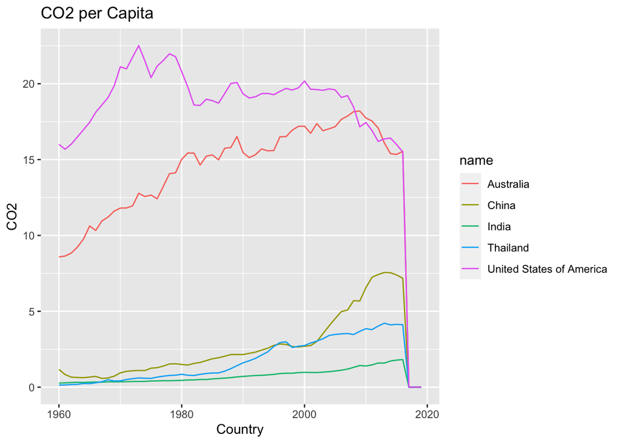

```r
ggplot(co2PC_continents, aes(x = time, y = co2_pc, color = name)) +
  geom_line() +
  labs(title = "CO2 per Capita",
       x ="Country",
       y = "CO2")
```

4. Compute average CO2 emissions per capita across the continents (assume region is the, same as continent). Comment what do you see.

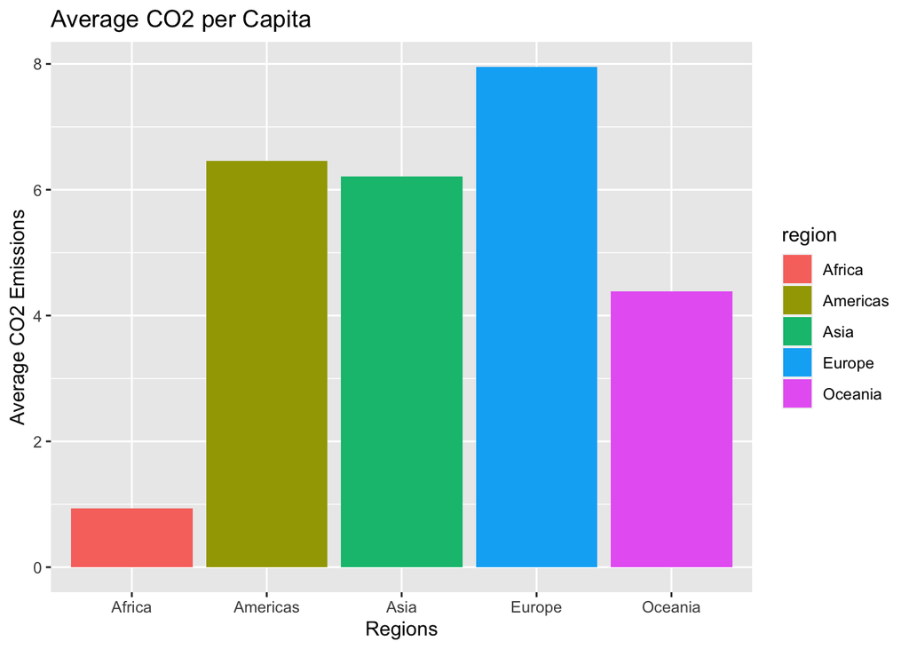

```r
average_co2 <- gapminder %>%
  filter(!is.na(co2_PC), !is.na(region)) %>%
  filter(name != "") %>%
  group_by(region) %>%
  summarize(average_emissions = mean(co2_PC), .groups = "keep")

ggplot(average_co2, aes(x = region, y = average_emissions, fill = region)) +
  geom_col() +
  labs(title = "Average CO2 per Capita",
       x = "Regions",
       y = "Average CO2 Emissions")
```

Europe has the highest averages of CO2, followed by roughly similar amounts between Americas, Asia, and Oceania. Africa has the most different, and lowest amounts.

5. Make a barplot where you show the previous results–average CO2 emissions per capita across continents in 1960 and 2016.

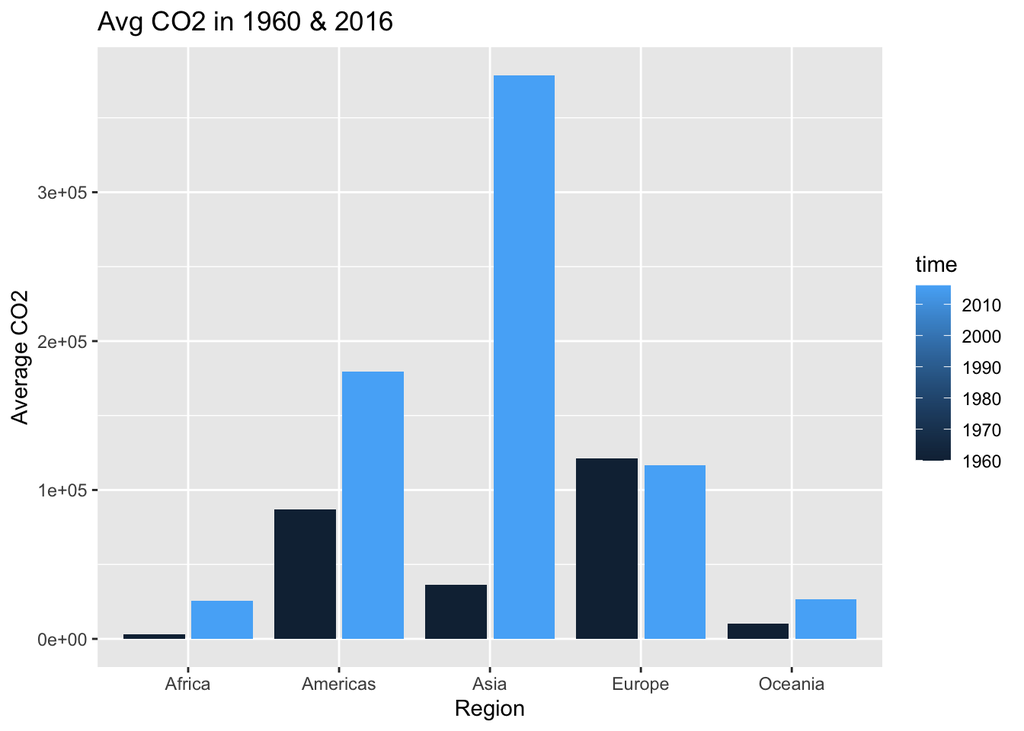

```r
years <- c("1960", "2016")
avg_co2_emissions <- gapminder %>%
  filter(!is.na(co2_PC), !is.na(region)) %>%
  filter(name != "") %>%
  filter(time %in% years) %>%
  group_by(time, region) %>%
  summarize(avg_co2 = mean(co2), .groups = "keep")

ggplot(avg_co2_emissions, aes(x = region, y = avg_co2, fill = time)) +
  geom_bar(stat = "identity", position = position_dodge2(0)) +
  labs(title = "Avg CO2 in 1960 & 2016",
       x = "Region",
       y = "Average CO2")
```

In almost all regions, 2016 shows a higher increase in average CO2, most noticeably in Asia. However, this does not include Europe, which has a lower average CO2 in 2016.

6. Which countries are the three largest, and three smallest CO2 emitters (in terms of CO2 per capita) in 2019 for each continent? (Assume region is continent).

Asia:

```r
gapminder %>%
  filter(is.na(co2_PC)) %>%
  filter(region == "Asia") %>%
  filter(time == "2019") %>%
  group_by(name) %>%
  summarize(avg_co2PC = mean(co2_PC)) %>%
  arrange(avg_co2PC) %>%
  head(3) %>%
  pull(name)
```

```
## [1] "Afghanistan" "Armenia"     "Azerbaijan"
```

America:

```r
gapminder %>%
  filter(is.na(co2_PC)) %>%
  filter(region == "Americas") %>%
  filter(time == "2019") %>%
  group_by(name) %>%
  summarize(avg_co2PC = mean(co2_PC)) %>%
  arrange(avg_co2PC) %>%
  head(3) %>%
  pull(name)
```

```
## [1] "Antigua and Barbuda" "Argentina"           "Aruba"
```

Africa:

```r
gapminder %>%
  filter(is.na(co2_PC)) %>%
  filter(region == "Africa") %>%
  filter(time == "2019") %>%
  group_by(name) %>%
  summarize(avg_co2PC = mean(co2_PC)) %>%
  arrange(avg_co2PC) %>%
  head(3) %>%
  pull(name)
```

```
## [1] "Algeria" "Angola"  "Benin"
```

Europe:

```r
gapminder %>%
  filter(is.na(co2_PC)) %>%
  filter(region == "Europe") %>%
  filter(time == "2019") %>%
  group_by(name) %>%
  summarize(avg_co2PC = mean(co2_PC)) %>%
  arrange(avg_co2PC) %>%
  head(3) %>%
  pull(name)
```

```
## [1] "Albania" "Andorra" "Austria"
```

Oceania:

```r
gapminder %>%
  filter(is.na(co2_PC)) %>%
  filter(region == "Oceania") %>%
  filter(time == "2019") %>%
  group_by(name) %>%
  summarize(avg_co2PC = mean(co2_PC)) %>%
  arrange(avg_co2PC) %>%
  head(3) %>%
  pull(name)
```

```
## [1] "American Samoa" "Australia"      "Fiji"
```

## 4. GDP per capita

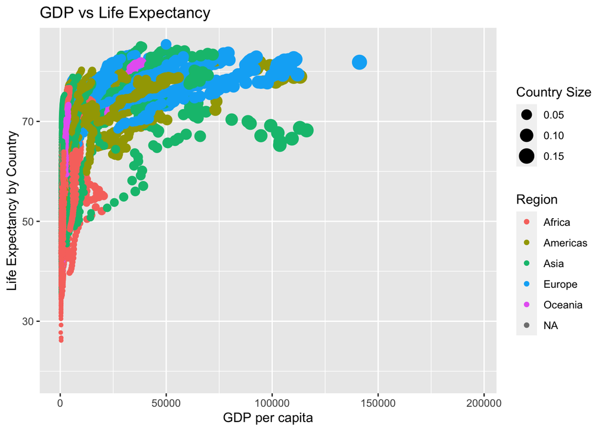

```r
gdp_vs_le <- gapminder %>%
  group_by(name) %>%
  filter(name != "")

ggplot(gdp_vs_le, aes(x = GDP_PC, y = lifeExpectancy, color = region, size = GDP_PC*0.000001)) +
  geom_point() +
  labs(title = "GDP vs Life Expectancy",
       x = "GDP per capita",
       y = "Life Expectancy by Country",
       size = "Country Size",
       color = "Region")
```

2. Make a similar plot, but this time use 2019 data only.

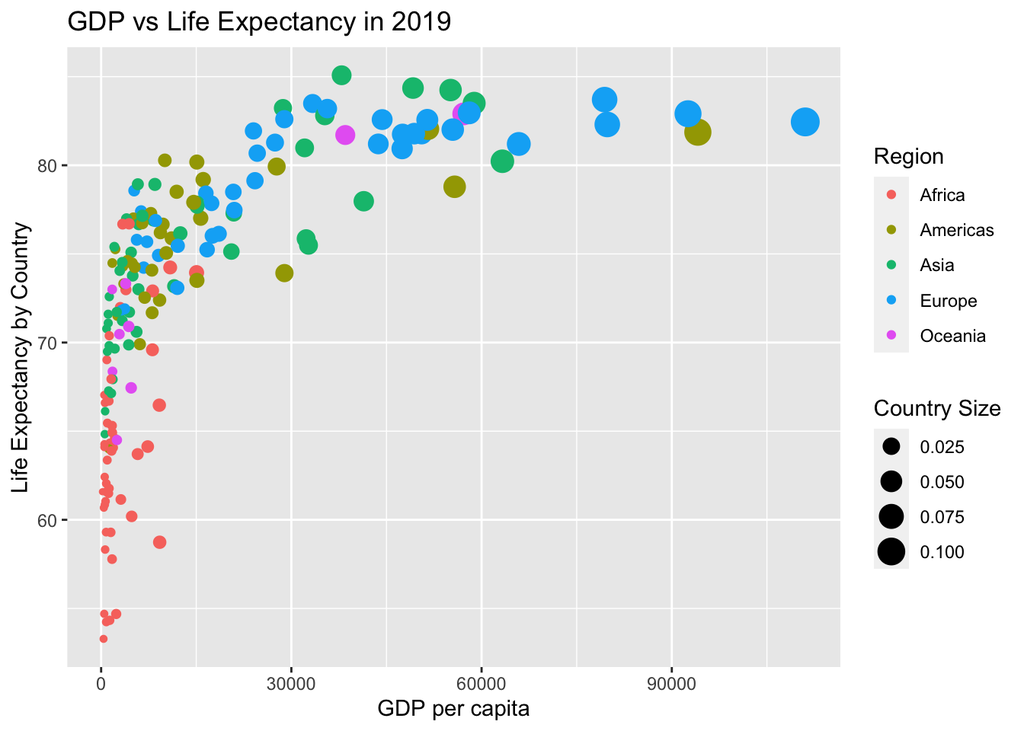

```r
gdp_vs_le2019 <- gapminder %>%
  group_by(name, time) %>%
  filter(time == "2019") %>%
  filter(name != "")

ggplot(gdp_vs_le2019, aes(x = GDP_PC, y = lifeExpectancy, color = region, size = GDP_PC*0.000001)) +
  geom_point() +
  labs(title = "GDP vs Life Expectancy in 2019",
       x = "GDP per capita",
       y = "Life Expectancy by Country",
       size = "Country Size",
       color = "Region")
```

3. Compare these two plots and comment what do you see. How has world developed through the last 60 years?

4. Compute the average life expectancy for each continent in 1960 and 2019. Do the results fit with what do you see on the figures?

```r
gapminder %>%
  group_by(region) %>%
  filter(time == "2019") %>%
  filter(!is.na(lifeExpectancy)) %>%
  summarize(mean(lifeExpectancy))
```

```
## # A tibble: 6 × 2
##   region   `mean(lifeExpectancy)`
##   <chr>                     <dbl>
## 1 Africa                     64.1
## 2 Americas                   75.8
## 3 Asia                       74.6
## 4 Europe                     79.4
## 5 Oceania                    73.5
## 6 <NA>                       77.8
```

```r
gapminder %>%
  group_by(region) %>%
  filter(time == "1960") %>%
  filter(!is.na(lifeExpectancy)) %>%
  summarize(mean(lifeExpectancy))
```

```
## # A tibble: 6 × 2
##   region   `mean(lifeExpectancy)`
##   <chr>                     <dbl>
## 1 Africa                     41.5
## 2 Americas                   58.6
## 3 Asia                       51.6
## 4 Europe                     68.3
## 5 Oceania                    56.4
## 6 <NA>                       70.7
```

5. Compute the average LE growth from 1960-2019 across the continents. Show the results in the order of growth. Explain what do you see.

```r
gapminder %>%
  group_by(region) %>%
  filter(time == "1960", time == "2019") %>%
  summarize(avg = mean(lifeExpectancy))
```

```
## # A tibble: 0 × 2
## # … with 2 variables: region <chr>, avg <dbl>
```

6. Show the histogram of GDP per capita for years of 1960 and 2019. Try to put both histograms on the same graph, see how well you can do it!

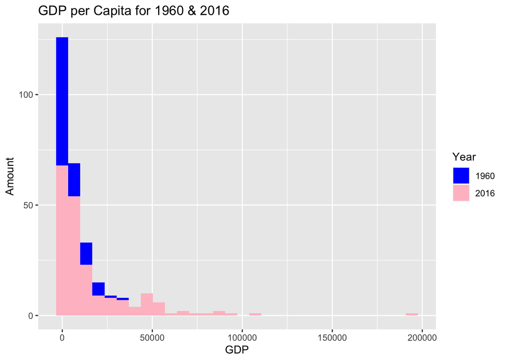

```r
gapminder %>%
  filter(!is.na(GDP_PC), time %in% c("1960", "2016")) %>%
  ggplot(aes(x = GDP_PC, fill = as.factor(time))) +
  geom_histogram() +
  scale_fill_manual(values = c("blue", "pink"), labels = c("1960", "2016")) +
  labs(title = "GDP per Capita for 1960 & 2016",
       x = "GDP",
       y = "Amount",
       fill = "Year")
```